# Psychological and Emotional Effects of Social Media on Students

The Matrix

Shaun Campbell (Team Leader)

Nan Yang; Ziwei Zhao; Shuqing Zhao

STAT 302: Accelerated Introduction to Statistical Methods

6 December 2018

# Introduction

Social media has a wide-reaching presence in modern-day society. Usage of social media seems particularly prevalent among young people, such as college students. Platforms such as Instagram, Facebook, Snapchat, and Twitter provide entertainment as well as a way for students to communicate. A problem presents itself in the potential effects of over-exposure to social media. These potential effects may or may not include psychological and emotional effects on a person, which can be measured by an effect on real-life relationships, an effect on academic performance, and effects on sleep, happiness, and stress. Finding whether social media use is associated with effects on these psychological and emotional measures serves as the motivation for this study.

The effects of social media on people’s lives are not entirely know, as social media is fairly new with popularity growing over the last decade. In 2013 Kross et al published a study that found that an increase in Facebook usage predicted a negative shift in how people feel moment-to-moment and how satisfied they are with their lives$^1$. In 2012, Pantic I, Damjanovic A, Todorovic J, et al published a study that found that online social networking has a statistically significant positive correlation with depression scores in high school students$^2$.

Since these studies were published, social media use has risen greatly. For example, Facebook use has risen from around 57% of US adults using the platform in 2013 to 68% in 2018, and Instagram use has risen from around 17% in 2013 to 35% in 2018$^3$. This study aims to take a new look on the effects of social media use specifically in college students at UW-Madison. The study will use different measures of specific emotional and psychological areas to generate a broader understanding of the effects of social media on emotional and psychological factors. Due to the growing amounts of time people are spending on social media platforms, it is important to study whether this has positive or negative effects. Researching this will hopefully reveal if social media use has a negative effect on students’ wellness and should be moderated, or if it has a positive effect and should be encouraged. The objective of this study is to find whether social media is associated with positive, negative, or no psychological and emotional effects on students.

To examine the effects of social media on the lives of students, several measures will be looked at. The psychological and emotional effects that are measured include the following: time spent face-to-face with friends; the student’s self-rating of their stress level, happiness level, and level of satisfaction with real-life relationships; GPA; level of sleep. These measures will give a sense of the psychological and emotional state of the students.

# Methods

The population of interest for this study is all undergraduate college students at UW-Madison. The interest in effects on students and the nature of testing resources leads to this being the best population to study. An observational study through the administration of a survey will be conducted in order to find associations within the data that can be applied to the population of interest.

Data will be collected using an online survey sent out to undergraduate students at the University of Wisconsin-Madison. The members of the research group will speak with academic advisors and lecturers for assistance with disseminating the survey to as broad an audience as possible. The survey will be distributed via email to statistics students and business students. The data that is collected through responses to the survey will be the subject of our study for this research.

The sampling in the study is not truly random because the distribution of the survey will not be truly random, and a truly random sample of every student at UW-Madison will not be able to be obtained. However, the sample will be unpredictable enough that an adequate proxy for our population will be obtained and appropriate for statistical tests and analysis. Since recipients of the survey will have the option of whether to take the survey, there will also be some response bias and non-response bias. These biases will be dealt with in the analysis of findings. As for sample size, the sample size will need to be large enough to be approximately normally distributed for quantitative variables, so ideally $>30$ responses. Categorical variables must also satsitfy $n_i p_i \geq 10$ and $n_i(1-p_i) \geq 10$ for each level of our categorical variables. It would also be ideal for the proportions of potential confounding variables such as gender to match that of the population.

#### Potential Confounding Variables

| Variable Name | Variable Type | Description | Variable Level |
| --- | --- | --- | --- |
| Year | Categorical | Class Standing | Freshman; Sophomore; Junior; Senior; 5th Year+ |
| Major | Categorical | Major of the student | Write-in |
| Gender | Categorical | Which gender the student is | Male; Female; Non-Binary; Gender Fluid |
| Ethnicity | Categorical | Ethnic origin of the student | White; Hispanic/Latino; Black/African American; Native American/American Indian; Asian/Pacific Islander; Other |
| Extroverted | Categorical | Whether the student describes themselves as extroverted or introverted | Extrovert; Introvert |

#### Explanatory Variables: Social Media

| Variable Name | Variable Type | Description | Variable Level |
| --- | --- | --- | --- |
| MostUsed | Categorical | The app the student spends the most time using | Snapchat; Instagram; Facebook; Other |
| TimeUse | Categorical | The time of day that the student most commonly uses social media | Morning; afternoon; evening; night |
| PrimaryUse | Categorical | The primary reason the student uses social media | News; Entertainment; Communication; ; Study; Killing Time; Other |
| TimeOfDay | Quantitative | Hours per day the student spends on social media |  |
| LikesPerDay | Quantitative | Number of likes/shares a student sends on Facebook per day |  |
| Post | Numerical | How many social media posts the student makes per week |  |
| Like | Numerical | How many followers the student has on Instagram |  |

#### Response Variables

| Variable Name | Variable Type | Description | Variable Level |
| --- | --- | --- | --- |
| FacetoFace | Categorical | Whether the student prefers to talk to their friends in person or online | In person; electronic devices |
| StressLevel | Categorical | The student’s rating of their stress level | 1-10 |
| HappinessLevel | Categorical | The student’s rating of their happiness | 1-10 |
| Satisfaction | Categorical | How the student rates their satisfaction with their real-life relationships | Very Dissatisfied; Somewhat Dissatisfied; Neutral; Satisfied; Very Satisfied |
| GPA | Quantitative | The student’s GPA |  |
| Sleep | Quantitative | Hours the student sleeps on average |  |
| TimeWithFriends | Quantitative | Hours spent with friends in real-life per week |  |
| EffectOnVacation | Categorical | If the student spends more time on social media on vacation | Definitely not; probably not; might or might not; Probably; Definitely |
| EffectOnExam | Categorical | If the student spends more time on social media in exam weeks | Definitely not; probably not; might or might not; Probably; Definitely |
| EffectOnAcademic Performance | Categorical | If the student believes social media affects academic performance | Yes; no |
| EffectPositiveOr Negative | Categorical | The effect the student believes social media has on them | Extremely positive; Moderately positive; slightly positive; neither positive nor negative; slightly negative; moderately negative; extremely negative |

#### Statistical Tests

The explanatory variables are split into groups to test for difference of means for different groups of the explanatory variables. Groupings that are analyzed include low social media use and high social media use, low stress and high stress, and gender. It is hypothesized that spending lots of time on social media may be associated with an increased stress level and gender may be a confounding variable. Therefore, it is appropriate to test for a difference of means between the groups. Statistical tests such as randomization and t-test are used to test for statistical significance. A regression is also performed to test for a relationship between hours of social media use time per day and GPA. R and RStudio with dplyr and ggplot2 packages are used to clean, visualize, and analyze the data. The results of the statistic tests performed with R are used to generate confidence intervals for the relevant test statistics which are then interpreted.

# Results

#### Gender Versus Time Spent on Social Media

This test aims to test a potential confounding variable of gender on time spent on social media. Time spent on social media is an important measure for this study and the removal of a confounding variable would help with interpretation of results. The variable “Gender” is used to split the data into male and female groups. It is hypothesized that the mean use time is the same for both genders. Therefore, the null and alternative hypotheses for this test are: $H_0$: $\mu_{\text{male}} = \mu_{\text{female}}$$H_a$: $\mu_{\text{male}} \neq \mu_{\text{female}}$The following are histograms that show the distribution of social media use time for males and females:

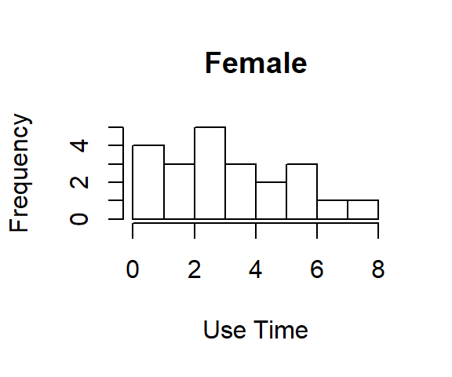

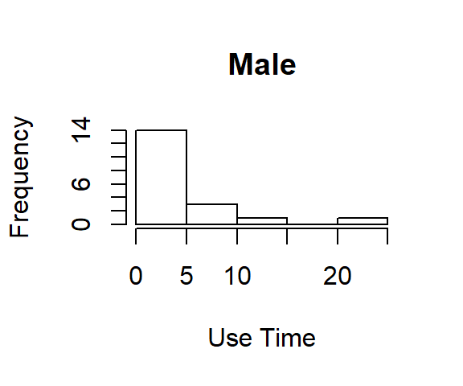

The following box-plot shows the distrubitions of use time for the two genders:

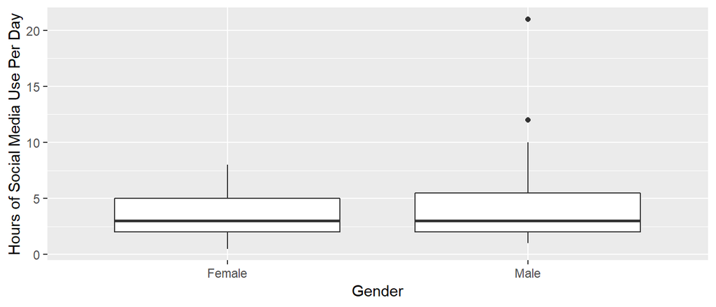

R is used to perform a two-sided t-test to analyze whether the average use time is different for males and females. The following summarizes the test statistic and the p-value (Appendix, 1)

| $\bar{X}_{\text{female}}$ - $\bar{X}_{\text{male}}$ | `-1.3684211` |
| --- | --- |
| P-Value | `0.2745706` |

The 95% confidence interval for the difference in means is [`-3.8957228`, `1.1588807`)

The results imply that there is not a statistically significant relationship between gender and average hours of social media use per day. This result can be used to remove gender as a confounding variable for hours of social media use per day which may be helpful for analysis of other results.

#### Social Media Use Time Per Day Depending on Stress Level

This test aims to find an association between stress level and time spent on social media per day. The variable “StressLevel” from the data is used to split that data into high stress (> 5) and low stress ($\leq$ 5) groups. Average social media use time per day is calculated using the “TimeOfDay” variable. It is hypothesized that students with low stress spend a different amount of time on social media than students with high stress. The null and alternative hypotheses are as follows:

$H_0\!: \mu_{\text{low}} = \mu_{\text{high}}$  
$H_a\!: \mu_{\text{low}} \neq \mu_{\text{high}}$

The following graphs visualize the data for social media use time for different levels of stress.

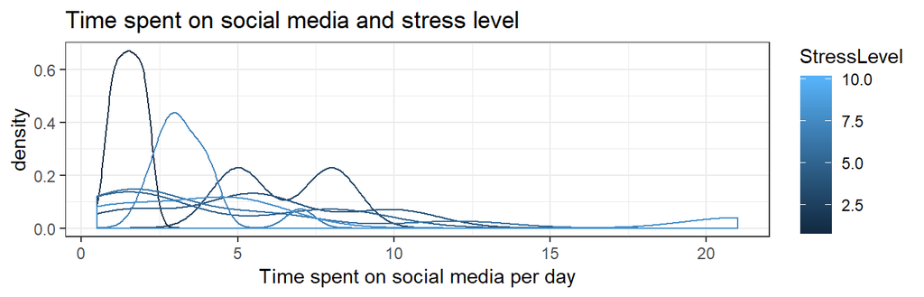

[figure not shown]

R is used to calculate the test statistic and p-value using a randomization test (Appendix, 2). The means of the high stress group and low stress group are shifted in order to do the randomization test. Bootstrap samples are created for each group using sampling with replacement for 10,000 samples. Means for each bootstrap sample are calculated and the difference of means for the bootstrap samples are calculated. The p-value is the proportion of bootstrap difference of means that are more extreme than the difference of means from the original sample. Below is a graph visualizing the bootstrap distribution with the difference of means from the original sample marked on the distribution.

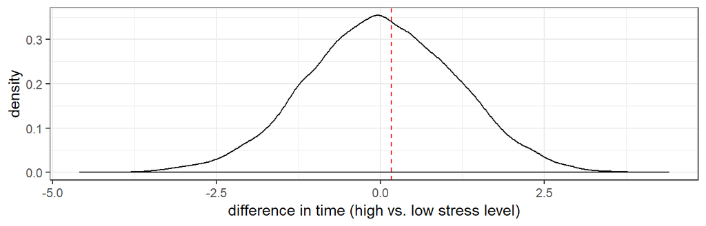

The following summarizes the test statistic and the p-value:

| $\bar{X}_{\text{low}}$ - $\bar{X}_{\text{high}}$ | `0.1637931` |
| --- | --- |
| P-Value | `0.8816` |

The 95% confidence interval using a t-distribution with 11 degrees of freedom and the standard error of the bootstrap difference in means is (`-1.8772749`, `2.2048611`)The p-value is quite large, so it cannot be said that students with a self-rated stress level of > 5 have a different social media use time per day than students with a stress level of $\leq$ 5.

#### Stress Level Depending on Hours of Daily Social Media Use

This test also aims to find an association between more hours per day spent on social media and higher stress levels in a different way. The variable “TimeOfDay” will be used to split the data into “High Use” and “Low Use” groups. “High Use” is defined as greater than or equal to 3 hours of social media use per day, and “Low Use” is defined as less than 3 hours per day for the purposes of this test. It is hypothesized that more social media use is associated with higher stress levels. Therefore, the null and alternative hypotheses for this test are as follows:$H_0:$ $\mu_{\text{high}}$ - $\mu_{\text{low}}$ = 0$H_a:$ $\mu_{\text{high}}$ - $\mu_{\text{low}}$ > 0

The following box-plots show the distribution of StressLevel for the High Use group and Low Use group:

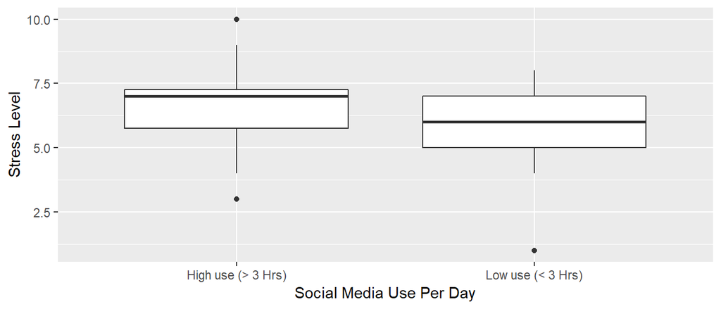

R is used to perform a one-sided t-test to analyze whether the average StressLevel for the High Use group is greater than the low use group (Appendix, 3). The following summarizes the test statistic and the p-value.

| $\bar{X}_{high}$ - $\bar{X}_{low}$ | `1.1642157` |
| --- | --- |
| P-Value | `0.0456357` |

The 95% confidence interval for the difference in means is [`0.0316975`, $\infty$)

The result implies that there is a statistically significant relationship between high social media use and higher self-reported stress level. Use of social media over 3 hours per day versus less than 3 hours per day is associated with a higher stress level of 1.16 on average. It can be said with 95% confidence that the average StressLevel for students in the population that use social media more than 3 hours per day is higher than the average StressLevel for students in the population that use social media less than 3 hours per day.

#### Hours of Social Media Per Day Versus GPA

This test aims to test whether the hours per day a student spends on social media is associated with the student’s GPA. The variable “Hours” is used to attempt to build a linear regression model to predict GPA. It is hypothesized that time spent on social media is associated with a higher or lower GPA. Therefore the null and alternative hypotheses for this test are:$H_0: \beta = 0$$H_a: \beta \neq 0$

The following graph displays a scatterplot of the data with a linear regression line (Appendix, 4).

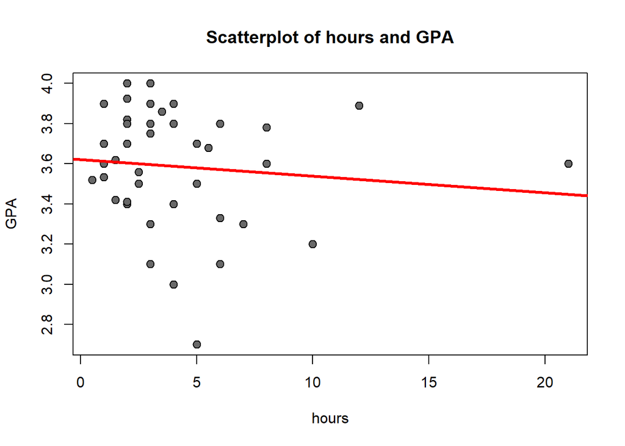

The following summarizes the test statistic and p-value for the simple linear regression (Appendix, 4):

| t-score for 0 | `-0.6657133` |
| --- | --- |
| P-Value | `0.51` |

THe 95% confidence interval for the slope of the regression line is [`-0.0335782`, `0.0169487`].

The results imply that there is no significant relationship between hours of social media use per day and GPA.

# Discussion of Results

The objective of this study is to find whether social media use is associated with positive, negative, or no psychological and emotional effects on students at UW-Madison. In original analysis of the data, it appeared that there may be significant effects on students’ self-reported stress level in particular. The analysis of the data thus focuses on associations between certain categorical variables and self-reported stress levels.

First it is relevant to understand whether gender is a confounding variable on social media use time per day. A two-sided t-test uncovers that there is no statistically significant relationship between gender and average social media use time per day. Gender can then be said to have no significant effect on social media use time, so if stress is found to have an association, gender can be discounted as a confounding variable. The sample size for each gender is not > 30, so the central limit theorem cannot be applied. A t-distribution is instead used to calculate the p-value and confidence interval, which is more conservative and accounts for the sample size being smaller than it should be ideally. This issue could be resolved with a larger sample size.

Next it is tested to see whether social media use time is associated with stress level. The data is split by stress level into groups of a stress level > 5 and $\leq$ 5. The difference of mean average social media use time per day is calculated and a randomization test results in no statistically significant relationship being found. It can be seen by the density plot of the randomization distribution that the distribution is normal so no assumptions are violated. A t-distribution is used to account for this when calculating the confidence interval to account for a sample size < 30. Since no statistically significant association is found, the results of this test do not help answer the research question.

Another method is used to find an association between hours per day spent on social media and self-reported stress level. Students in the sample that use social media for $\geq$ 3 hours per day on average have a higher stress level by 1.16 on average than those who use social media for < 3 hours per day. A one-sided t-test shows that the results is significant at the $\alpha = 0.05$ level and the results can therefore be said to be statistically significant. Again the sample size for each group is < 30 so a t-distribution is used when calculating p-value and a confidence interval. The use of a difference of means test is questionable because the StressLevel variable is categorical and not a continuous numerical variable. However, a distribution of bootstrap sample means appears to be normally distributed. This issue could be resolved by using a different measure of stress, such as a score on a standardized test that yields a numerical value.

However, it can be seen by the box-plot for the distribution of stress levels for High Use and Low Use groups that the High Use group is skewed due to an outlier. Removal of this outlier would change the average StressLevel for the High Use group from 6.46 to 6.30. A t-test performed with the outlier removed shows that the results are no longer significant. The statistical tests also assume that the sample is truly random, and this is not the case. The sample is not truly random and since the results are not significant if a single outlier is removed, the association cannot be rationally applied to the population. The results of this test therefore do not help to answer the research question.

The data is also analyzed to see if there is any significant relationship between hours spent on social media per day and GPA. The variable TimeOfDay is used as the explanatory variable and the variable GPA is used as the response variable for a simple linear regression. The regression shows no significant linear relationship between the two variables. Looking at the scatterplot of the two variables, there appears to be no relationship. This test implies that there is not a negative or positive effect of social media use on academic performance and instead implies that there is no effect.

Given more time and resources, the assumptions that are violated could be resolved. A more random sample with a much larger sample size could be obtained by taking all students at UW-Madison, choosing randomized sample of all students, and having each one of them that is chosen take the survey. The underlying sample should then be normal and resilient to outliers and the central limit theorem could be applied for tests. Any results could then be applied to the population of interest.

Ideally, a different form of study other than a survey would be performed. The survey, which asked how much time a student spends on social media per day, is based on having the student estimate the figure. A study could instead be performed that more closely monitors the exact amount time the student spends on social media. Instead of having the student rate their stress level on a scale, the student could take a test such as the BDI-II-II test taken in the study performed by Pantic I, Damjanovic A, Todorovic J, et al$^2$. The data collected in place of a self-report of stress level would be more accurate and much less subjective. The results would then be more easily applied to the population.

# Appendix

1. T-test for Gender and TimeOfDay

```r
raw_file = read.csv("C:/Users/shaun/Documents/Book1.csv")
data = subset.data.frame(raw_file,select = c(Gender,TimeOfDay))
p.value = t.test(x = data$TimeOfDay[data$Gender=="Female"],
                 y = data$TimeOfDay[data$Gender=="Male"])$p.value
mean_diff  = mean(data$TimeOfDay[data$Gender=="Female"]) -
                mean(data$TimeOfDay[data$Gender=="Male"])
CI.lower = t.test(x = data$TimeOfDay[data$Gender=="Female"],
                  y = data$TimeOfDay[data$Gender=="Male"])$conf.int[1]
CI.upper = t.test(x = data$TimeOfDay[data$Gender=="Female"],
                  y = data$TimeOfDay[data$Gender=="Male"])$conf.int[2]
```

2. Randomization test for difference in means, TimeOfDay and StressLevel

```r
MyData <- read.csv(file="C:/Users/shaun/Documents/Book1.csv", header=TRUE, sep=",")
NewData <- subset(MyData,
select=c(StressLevel, TimeOfDay))
low = NewData$TimeOfDay[NewData$StressLevel<=5]
high = NewData$TimeOfDay[NewData$StressLevel>5]
mlow = mean(low)
mhigh = mean(high)
mdiff = mlow - mhigh

low = NewData$TimeOfDay[NewData$StressLevel<=5]
high = NewData$TimeOfDay[NewData$StressLevel>5]
mean.l = mean(low)
mean.h = mean(high)
mean.all = mean(c(low,high))
## null samples with equal means
low0 = low - mean.l + mean.all
high0 = high - mean.h + mean.all
## Randomization
B = 10000
n.l = length(low)
mat.l = matrix(sample(low0,size=B*n.l,replace=TRUE), B, n.l)
n.h = length(high)
mat.h = matrix(sample(high0,size=B*n.h,replace=TRUE), B, n.h)
rand.l = apply(mat.l,1,mean)
rand.h = apply(mat.h,1,mean)
rand.diff = rand.l - rand.h
## p-value
p.value = mean( abs(rand.diff) >= abs(mean.l - mean.h) )
## Graph the randomization distribution
df = data.frame(rand.diff)
ggplot(df, aes(x=rand.diff)) +
  geom_density() +
  geom_vline(xintercept=mean.l-mean.h, color="red",linetype="dashed") +
  xlab('difference in time (high vs. low stress level)') +
  theme_bw()
```

3. T-test for TimeOfDay and StressLevel

```r
data3 <- read.csv(file="C:/Users/shaun/Documents/Book1.csv",header=TRUE)
low_use <- data3$StressLevel[data3$TimeOfDay < 3 & !is.na(data3$StressLevel)]
high_use <- data3$StressLevel[data3$TimeOfDay >= 3 & !is.na(data3$StressLevel)]
p.value = t.test(x=high_use,y=low_use, alternative = "greater")$p.value
mean_diff  = mean(high_use) - mean(low_use)
CI.lower = t.test(x=high_use,y=low_use, alternative = "greater")$conf.int[1]
```

4. Regression of GPA on TimeOfDay

```r
gpa <- c(3, 3.5, 3.86, 3.9, 3.1, 3.7, 3.68, 3.8, 3.8, 3.82, 4, 3.89, 3.8, 3.33, 3.56, 3.4,
         3.925, 4, 3.9, 3.8, 3.7, 3.62, 3.42, 3.9, 3.534, 3.2, 3.3, 3.6, 3.7, 2.7, 3.3, 3.4,
         3.75, 3.78, 3.6, 3.41, 3.52, 3.1, 3.6, 3.5, 3.7)
hours <- c(4, 2.5, 3.5, 3, 3, 2, 5.5, 3, 6, 2, 3, 12, 2, 6, 2.5, 2, 2, 2, 4, 4, 5, 1.5, 1.5,
           1, 1, 10, 3, 1, 1, 5, 7, 4, 3, 8, 21, 2, 0.5, 6, 8, 5, 1)
model <- lm(gpa ~ hours)
plot(hours, gpa, pch=21, bg="dimgray",cex=1.2,
     xlab="hours",ylab="GPA",main="Scatterplot of hours and GPA")
abline(model, lwd=3, col="red")
b1.hat = coef(model)[2]
dof=41-2
t = b1.hat/.012490
t.crit = qt(.975,dof)
CI.slope = b1.hat + c(-1,1)*t.crit*.012490
p.val = 0.51
```